# Molecular Marker Assisted Plant Breeding

Composite Interval Mapping (CIM)

Felipe Ferrão

University of Florida

**Objectives:**

- 60 minutes of hands-on
- Covariates and linear models
- Compositive interval mapping

**Extra information**

- [HOS 6236 – Website](https://lfelipe-ferrao.github.io/class/mas/)
- About the [author](https://lfelipe-ferrao.github.io/)
- About the [UF/IFAS Plant Breeding](https://programs.ifas.ufl.edu/plant-breeding/)

# Introduction

In the past two classes, we focused on approaches that consider one marker at a time. In the first scenario, we used single-marker regression, where each marker was tested individually for its association with the trait. This method treats the markers independently and does not account for linkage information between them.

We then extended this idea to interval mapping, which introduced the use of the linkage map to provide a more informative framework. Specifically, interval mapping incorporates the recombination fractions between markers and a potential QTL to compute the conditional probabilities of QTL genotypes, given the flanking markers. These probabilities are then used in a regression model to estimate QTL effects across the genome.

However, both single-marker and basic interval mapping methods can be influenced by background genetic variation—that is, other QTLs or loci that affect the trait but are not accounted for in the model. This brings us to the next important step: Composite Interval Mapping (CIM).

CIM enhances the interval mapping framework by including additional markers as covariates (also called cofactors) in the regression model. These markers are chosen to represent background genetic effects and help control for the influence of other QTLs. By doing so, CIM reduces the residual variance in the model and improves both the power to detect QTLs and the precision of their estimated positions.

From a statistical perspective, the main difference is that CIM uses a multiple linear regression model rather than a simple one. The model simultaneously tests for a QTL in a given interval while accounting for the effects of selected nearby markers. This adjustment helps isolate the effect of the QTL being tested and mitigates confounding caused by other segregating loci.

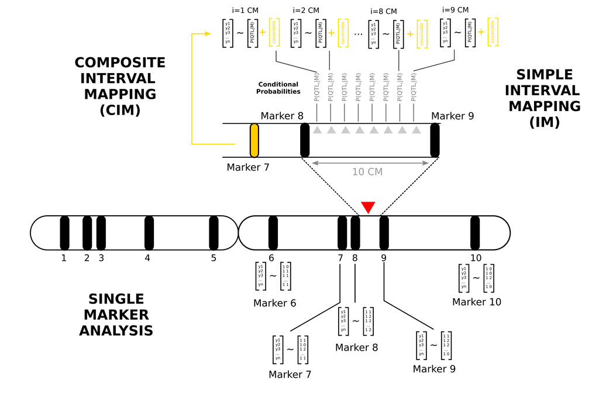

Example of composite vs. simple interval mapping vs. single marker regression

# Working with covariables

We will use a tow example to explore a common case of confounding using simulated data, and how the use of cofactors in the linear model can help on that. Here we simulated **hair length** and **height** of students. We observe a negative correlation between the two variables. At first glance, it seems that **taller students have shorter hair**. However, this trend is misleading.

The actual explanation is due to **gender**:

- **Males** tend to be **taller** and have **shorter hair**.
- **Females** tend to be **shorter** and have **longer hair**.

Below, we can write it into a statistical model:

$$\text{HairLength}_{ij} = \beta_0 +
\beta_1 \cdot \text{Height}_i + \beta_1 \cdot \text{Gender}_j +
\varepsilon_{ij}$$

- $\beta_0$: Intercept
- $\beta_1$: Effect of height on hair length
- $\varepsilon_i$: Residual error

```r
model1 <- lm(HairLength ~ Height, data = df)
model2 <- lm(HairLength ~ Height + Gender, data = df)
```

The example below show a regression analysis ignoring the gender effect (left hand) and therefore showing a significant p.value, while the next plot (right hand) shows the same data set but a statistical model where the gender effect is considered.

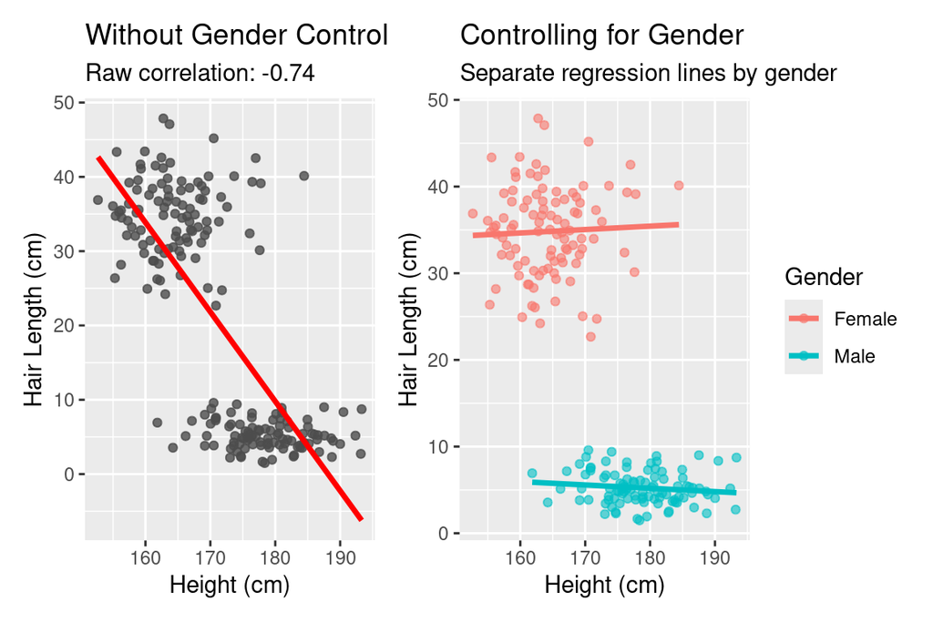

# Multiple Regression

**Multiple linear regression** is an extension of simple linear regression that models the relationship between one dependent variable and **two or more independent (predictor) variables**. It is used when we believe the outcome is influenced by multiple factors, and we want to understand how each one contributes to the variation in the response.

The general form of the multiple linear regression model is:

$$\mathbf{y} = \mathbf{X} \boldsymbol{\beta} + \boldsymbol{\varepsilon}$$

Where:

- $\mathbf{y}$ is the $n \times 1$ vector of response variables.
- $\mathbf{X}$ is the $n \times p$ matrix of predictors (including the intercept).
- $\boldsymbol{\beta}$ is the $p \times 1$ vector of regression coefficients.
- $\boldsymbol{\varepsilon}$ is the $n \times 1$ vector of random errors.

Let’s model the outcome $y$ using two predictors $x_1$ and $x_2$, and an intercept. These two predictor could be two different markers in the context of QTL mapping, or two different variables (irrigation and fertilizer levels, for example) explaining a variable under study (yield, for example)

$$y_i = \beta_0 + \beta_1 x_{1i} + \beta_2
x_{2i} + \varepsilon_i$$

In matrix notation (for $n = 3$ observations), the model becomes more compact and easy to be represented:

$$\begin{bmatrix}
y_1 \\
y_2 \\
y_3
\end{bmatrix}
=
\begin{bmatrix}
1 & x_{11} & x_{21} \\
1 & x_{12} & x_{22} \\
1 & x_{13} & x_{23}
\end{bmatrix}
\begin{bmatrix}
\beta_0 \\
\beta_1 \\
\beta_2
\end{bmatrix}
+
\begin{bmatrix}
\varepsilon_1 \\
\varepsilon_2 \\
\varepsilon_3
\end{bmatrix}$$

Here:

- The first column of 1’s represents the **intercept**.
- $x_1$ and $x_2$ are the predictors.
- $\beta_0, \beta_1, \beta_2$ are the coefficients we estimate.

The coefficients are estimated using **least squares**, minimizing the sum of squared residuals, as we presented in the previous classes as:

$$\hat{\boldsymbol{\beta}} =
(\mathbf{X}^\top \mathbf{X})^{-1} \mathbf{X}^\top
\mathbf{y}$$

There are several reasons to use multiple regression analyses. In the context of the CIM method, we introduced the idea of cofactors in the model and we will highlight the use of multiple regression models is to **control for extraneous sources of variation** (i.e., sources of variation that influence the response variable but are not of interest in and of themselves).

**But, why would we want to control for extraneous variation?**

One reason to use a multiple regression model is to increase power to detect treatment effects. Look the classical example below:

- Zeng (1994)
- IM vs. CIM methods.
- How many QTL do we have?

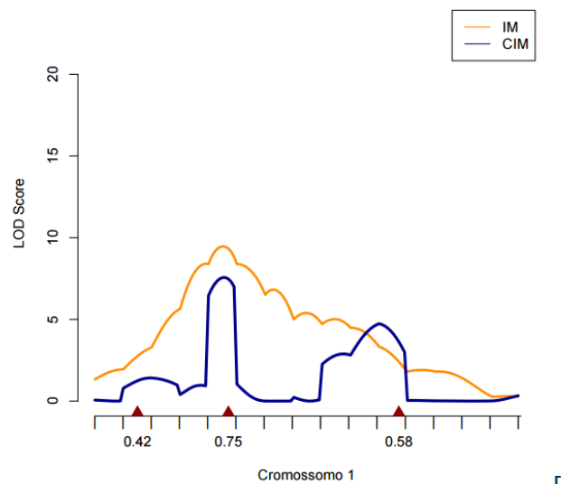

**The ghost QTL !**

This figure exemplifies the idea behind of **ghost QTL**. It is a false or misleading signal detected during QTL mapping that appears to indicate a true genetic effect, but actually arises from the combined influence of two or more nearby QTLs. When multiple real QTLs are close together on a chromosome, their effects can “blur” together, and interval mapping may incorrectly identify a single strong peak between them — the ghost. This happens because the method assumes only one QTL at a time in the interval being scanned. The ghost QTL illustrates why it’s important to consider multiple QTL models (e.g., composite interval mapping or multiple QTL mapping) to correctly separate overlapping effects and avoid being misled by artifacts of the model.

## Selecting co-factors

Now that we are moving into multiple regression analyses, a natural idea is to include **all available markers** (or predictors) in the model to explain the variation in the phenotype. However, this approach quickly runs into problems — especially in genomics, where the number of markers (predictors) can be **much larger than the number of observations** (samples).

When the number of predictors $p$ exceeds the number of observations $n$ (i.e., $p > n$), the standard linear regression model:

$$Y = \beta_0 + \beta_1 X_1 + \beta_2 X_2
+ \dots + \beta_p X_p + \varepsilon$$

becomes **non-identifiable**, meaning there are infinitely many solutions. In addition:

- The model will **overfit** the data.
- Many coefficients will appear significant **by chance**.
- The interpretation of the model becomes unstable and unreliable.

To address this, one approach is **stepwise regression**, which selects a subset of predictors that contribute the most to explaining the response variable.

In stepwise regression, the model:

$$Y = \beta_0 + \sum_{j \in S} \beta_j X_j
+ \varepsilon$$

Choosing the right subset of predictors is critical for building a model that is:

- **Parsimonious**: Simple enough to interpret and generalize.
- **Stable**: Less sensitive to noise or changes in data.
- **Effective**: Able to identify meaningful biological signals (e.g., QTLs).

In the example below, we demonstrate how stepwise regression works using a simple simulation. We generated data for 100 individuals with 10 predictors, where only three predictors (X1, X3, and X7) have a true effect on the response variable.

Stepwise regression iteratively adds and removes predictors, evaluating models based on criteria such as the Akaike Information Criterion (AIC) or adjusted R², to identify the most parsimonious model that balances complexity (number of parameters) and goodness-of-fit. This approach helps to avoid overfitting by including only relevant predictors and improves model interpretability while maintaining predictive power.

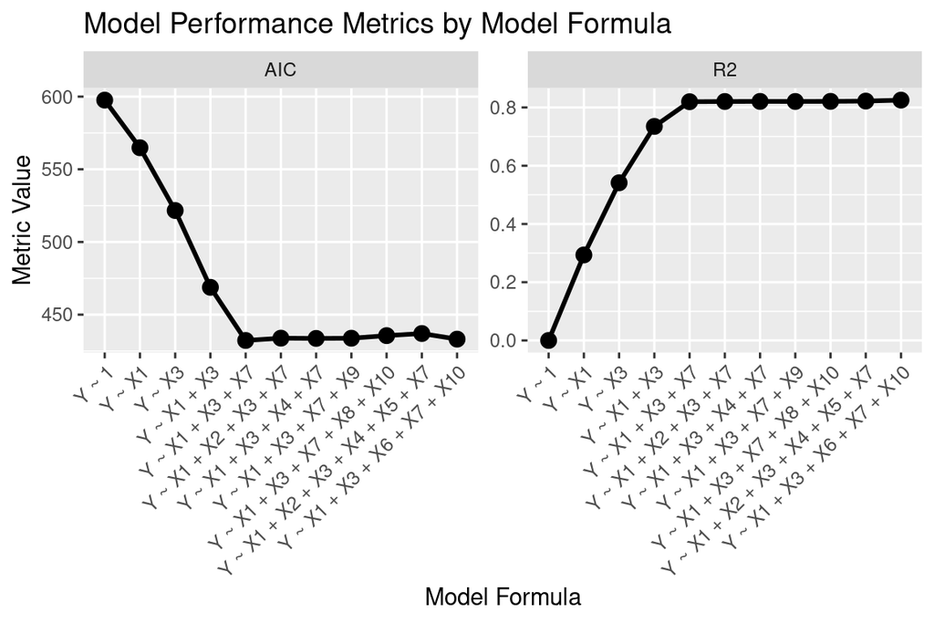

**important**

- R2 measures the proportion of variance explained by the model, it is not always a reliable indicator for model selection, especially when comparing models with different numbers of predictors. This is because R2 never decreases when additional variables are added.
- AIC provide a more robust method for evaluating model quality by penalizing model complexity. Models with lower AIC values are considered better because they achieve a good fit with fewer parameters, balancing goodness-of-fit and simplicity.

# Hands-on

For the sequence of this tutorial, we will keep using the same example from the Single Marker Regression and IM method

- Sugiyama et al., (2002): QTL associated with blood pressure, heart rate, and heart weight in CBA/CaJ and BALB/cJ mice. Physiol Genomics 10:5–12. [Link](https://journals.physiology.org/doi/full/10.1152/physiolgenomics.00002.2002)
- Number of individuals: 163
- 93 markers
- F2 population

```r
library(qtl)
sug <-  read.cross("csv",
                  "/home/felipe/Dropbox (UFL)/classes/Molecular_Breeding/class3_QTLMapping/",
                  "QTLmapping_6.csv",
                  genotypes=c("CC", "CB",   "BB"),
                  alleles=c("C",    "B"))
```

```
##  --Read the following data:
##   163  individuals
##   93  markers
##   6  phenotypes
##  --Cross type: f2
```

```r
# SINGLE MARKER REGRESSION
mr <- scanone(sug, pheno.col=3,method="mr")
summary(mr,threshold = 2.6) # QTL threshold > 2.5 (naive threshold)
```

```
##           chr  pos  lod
## D15MIT184  15 22.8 6.61
## D16MIT5    16 34.2 2.70
```

```r
# INTERVAL MAPPING
# -- Simple linear regression,considering a grid of positions along the genome
hyper = calc.genoprob(sug,step=1) # cond. prob
IM.hk = scanone(hyper, pheno.col = 3, method = "hk")
summary(IM.hk,threshold = 2.6) # QTL threshold > 2.5 (naive threshold)
```

```
##           chr  pos  lod
## c3.loc23    3 33.8 2.76
## c15.loc16  15 20.0 6.75
## c16.loc22  16 36.7 2.74
```

```r
# COMPOSITE INTERVAL MAPPING
# -- Multiple linear regression,considering a grid of positions along the genome
# -- Markers as covariates (reduce residual variation and increase the power)
set.seed(123)
CIM = cim(hyper, pheno.col = 3, n.marcovar=5, window=20)
summary(CIM,threshold = 2.6) # QTL threshold > 2.5 (naive threshold)
```

```
##           chr  pos  lod
## c14.loc31  14 43.5 2.83
## D15MIT184  15 22.8 8.07
## c19.loc14  19 17.4 2.77
```

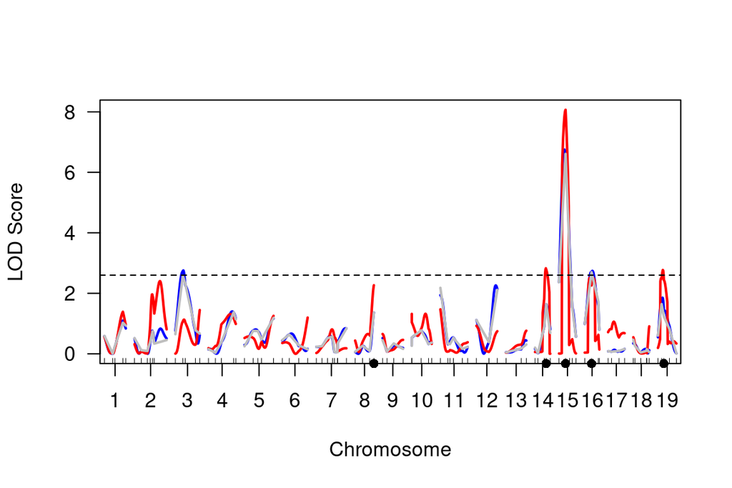

```r
# Ploting
chr <- c(1:19)
plot(IM.hk, CIM,mr, chr = chr, col = c("blue", "red","gray"), ylab = "LOD Score")
add.cim.covar(CIM, chr = chr, col = "black")
abline(h = 2.6, lty = 2, col="black") # naive threshold
```

**Questions**

- What are the problems to use a naive threshold ?
- Are there common QTL common across the methods ?
- Is there difference in magnitude of the hits ?
- What about increasing the window size or the number of covariates ?

**QTL effect**

- Look the marker at the chromosome 15. Check how the incorporation of co-factors in the CIM model changed the SE (deviations).

```r
# IM method
qtl.im = summary(IM.hk,threshold = 2.6)
qtl.im.make = makeqtl(hyper, chr = qtl.im$chr,pos=qtl.im$pos,what="prob")
qtl.eff.im = fitqtl(hyper,qtl=qtl.im.make,method="hk",get.ests=TRUE, dropone=FALSE)
summary(qtl.eff.im)
```

```
##
##      fitqtl summary
##
## Method: Haley-Knott regression
## Model:  normal phenotype
## Number of observations : 155
##
## Full model result
## ----------------------------------
## Model formula: y ~ Q1 + Q2 + Q3
##
##        df        SS        MS      LOD     %var Pvalue(Chi2)    Pvalue(F)
## Model   6  1856.284 309.38061 5.939604 16.17763 0.0001243424 0.0001824304
## Error 148  9618.103  64.98719
## Total 154 11474.387
##
##
## Estimated effects:
## -----------------
##                est       SE       t
## Intercept 104.8396   0.6567 159.658
## 3@33.8a     1.1640   0.8917   1.305
## 3@33.8d     1.5563   1.4194   1.096
## 15@20.0a   -4.8723   1.0134  -4.808
## 15@20.0d   -0.3298   1.4915  -0.221
## 16@36.7a   -0.6192   0.9522  -0.650
## 16@36.7d    2.7467   1.4410   1.906
```

```r
# CIM method
qtl.cim = summary(CIM,threshold = 2.6)
cov.position = attr(CIM, "marker.covar.pos")
qtl.cim.make = makeqtl(hyper, chr = cov.position$chr,pos=cov.position$pos,what="prob")
qtl.eff.cim = fitqtl(hyper,qtl=qtl.cim.make,
                     method="hk",get.ests=TRUE,
                     dropone=FALSE)
summary(qtl.eff.cim)
```

```
##
##      fitqtl summary
##
## Method: Haley-Knott regression
## Model:  normal phenotype
## Number of observations : 155
##
## Full model result
## ----------------------------------
## Model formula: y ~ Q1 + Q2 + Q3 + Q4 + Q5
##
##        df        SS        MS      LOD     %var Pvalue(Chi2)   Pvalue(F)
## Model  10  1789.632 178.96324 5.707168 15.59676   0.00337828 0.005193398
## Error 144  9684.755  67.25524
## Total 154 11474.387
##
##
## Estimated effects:
## -----------------
##                 est        SE       t
## Intercept 104.67976   0.66981 156.282
## 15@22.8a   -4.27385   0.96712  -4.419
## 15@22.8d   -0.70099   1.34821  -0.520
## 16@34.2a   -0.80562   0.93945  -0.858
## 16@34.2d    2.27017   1.34416   1.689
## 14@44.5a   -0.79447   0.94717  -0.839
## 14@44.5d    1.39235   1.36857   1.017
## 19@20.4a   -0.89974   1.00947  -0.891
## 19@20.4d    0.05292   1.36889   0.039
## 8@74.7a    -0.86335   0.90099  -0.958
## 8@74.7d    -1.69656   1.35523  -1.252
```

**Permutation**

In a permutation test, we estimate the distribution of the maximum LOD score under the null hypothesis (no QTL) by randomly shuffling the phenotypes. Here’s how it works:

- The genotype data remain fixed (i.e., the original marker genotypes are not changed).
- The phenotypic values are randomly reassigned to individuals, breaking any real associations between genotype and phenotype.
- The QTL mapping procedure (e.g., interval mapping with Haley-Knott regression) is applied to this permuted dataset, and the maximum LOD score across the genome is recorded.

This permutation process is repeated r times (commonly 1000 or 10,000 times), yielding a collection of maximum LOD scores under the null hypothesis. From this empirical distribution of null LOD scores, we can derive a genome-wide significance threshold by taking the 95th percentile.

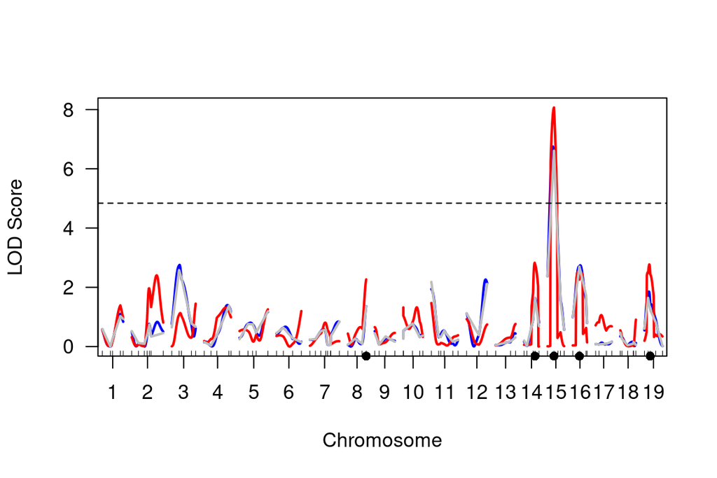

```r
# PERMUTATION
# -- Let's be more formal (!)
set.seed(123)
cim.perm = cim(hyper, pheno.col = 3, n.marcovar=5, window=20,n.perm = 10)
plot(IM.hk, CIM,mr, chr = chr, col = c("blue", "red","gray"), ylab = "LOD Score")
add.cim.covar(CIM, chr = chr, col = "black")
abline(h = summary(cim.perm)[1], lty = 2, col= "black") # threshold using permutation
```

# Conclusions

Composite Interval Mapping (CIM) represents a significant advancement in the detection and localization of QTL. By integrating interval mapping with multiple linear regression, CIM improves the precision and power of QTL analysis by accounting for background genetic variation through the inclusion of covariates (typically nearby markers). This approach helps to reduce residual variance and minimize the confounding effects of linked QTL, leading to more accurate estimates of QTL position and effect. While it requires careful selection of cofactors and model parameters, CIM remains a widely used and robust method in modern genetic analysis, providing a critical foundation for marker-assisted selection and downstream applications in plant and animal breeding.

# References

- Lander, E. S., & Botstein, D. (1989). *Genetics*, 121(1), 185–199.
- Broman, K. W., & Sen, Ś. (2009). *A Guide to QTL Mapping with R/qtl*. Springer.
- Haley, C. S., & Knott, S. A. (1992). *Heredity*, 69(4), 315–324.
- Lynch, M., & Walsh, B. (1998). *Genetics and Analysis of Quantitative Traits*.